# Block 2 ex 4

Facchin Tommaso

In an experiment on child development, some children were asked to build a tower as tall as possible using blocks: in a first trial the children were given cubes, while in a second trial they were provided with cylinders. Each child was tested twice (so each child built four towers). Information about the variables collected during the experiment can be found in the dataset `blocks` in the R package GLMsData (`data(blocks, package = "GLMsData")`).

```r
library(GLMsData)
data(blocks)
head(blocks)
```

```
##   Child Number  Time Trial Shape  Age
## 1     A     11  30.0     1  Cube 4.67
## 2     B      9  19.0     1  Cube 5.00
## 3     C      8  18.6     1  Cube 4.42
## 4     D      9  23.0     1  Cube 4.33
## 5     E     10  29.0     1  Cube 4.33
## 6     F     13 178.0     1  Cube 4.83
```

### 1. Produce a plot that investigates whether there is a relationship between the number of blocks used (Number) and the children’s age (Age).

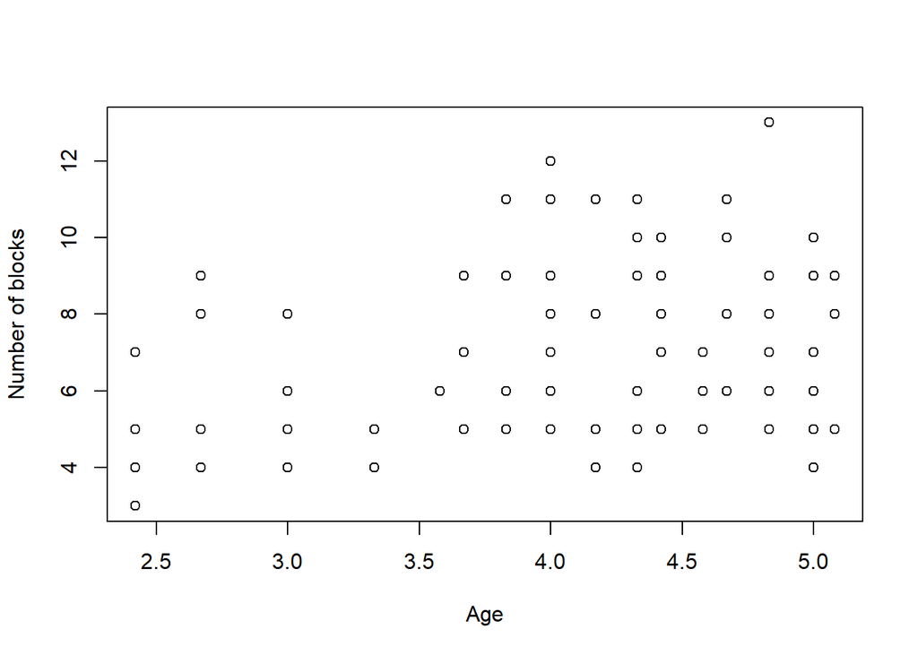

```r
plot(blocks$Age, blocks$Number,
     xlab = "Age",
     ylab = "Number of blocks")
```

### 2. Produce a plot that investigates whether the relationship between the number of blocks used (Number) and the children’s age (Age) differs depending on whether the blocks given to the children are cubes or cylinders (Shape).

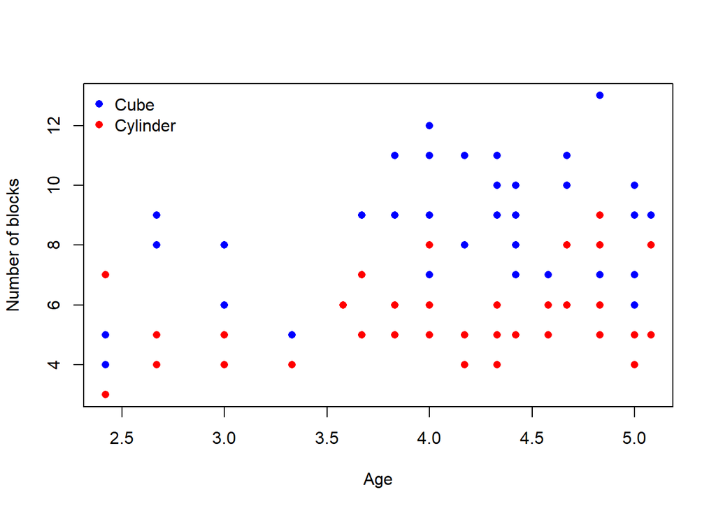

```r
cols <- c("Cube" = "blue", "Cylinder" = "red")

plot(blocks$Age, blocks$Number,
     col = cols[blocks$Shape],
     pch = 16,
     xlab = "Age",
     ylab = "Number of blocks")

legend("topleft",
       legend = c("Cube", "Cylinder"),
       col    = c("blue", "red"),
       pch    = 16,
       bty    = "n")
```

### 3. Use a GLM with the canonical link function to estimate a model in which the number of blocks used depends on the child’s age. Explain how the estimated regression coefficients can be interpreted. Construct a 98% confidence interval for the coefficient associated with Age.

```r
fit <- glm(Number~Age, data=blocks, family=poisson())
summary(fit)
```

```
##
## Call:
## glm(formula = Number ~ Age, family = poisson(), data = blocks)
##
## Coefficients:
##             Estimate Std. Error z value Pr(>|z|)
## (Intercept)   1.3447     0.2223   6.048 1.47e-09 ***
## Age           0.1415     0.0534   2.650  0.00805 **
## ---
## Signif. codes:  0 '***' 0.001 '**' 0.01 '*' 0.05 '.' 0.1 ' ' 1
##
## (Dispersion parameter for poisson family taken to be 1)
##
##     Null deviance: 69.429  on 99  degrees of freedom
## Residual deviance: 62.244  on 98  degrees of freedom
## AIC: 439.64
##
## Number of Fisher Scoring iterations: 4
```

```r
confint(fit, parm = "Age", level = 0.98)
```

```
## In attesa che venga eseguita la profilazione...
```

```
##        1 %       99 %
## 0.01851926 0.26706046
```

### 4. Construct a confidence interval for the number of blocks used by a child aged 4 and 9 years; comment on the reliability of these intervals.

```r
nd <- data.frame("Age" = c(4, 9))

pred = predict(fit, newdata=nd, type="link", se.fit=TRUE)

cbind(poisson()$linkinv(pred$fit + qnorm(.01) * pred$se.fit),
      poisson()$linkinv(pred$fit + qnorm(.99) * pred$se.fit))
```

```
##       [,1]     [,2]
## 1 6.176589  7.39430
## 2 7.413429 25.36268
```

These intervals suggest that the prediction for a 4‑year‑old child is reasonably precise, whereas the very wide interval for a 9‑year‑old indicates much greater uncertainty and therefore a less reliable estimate of the expected number of blocks.

### 5. Use a GLM with the canonical link function to estimate a model in which the number of blocks used depends on the child’s age (Age) and on the type of block provided (Shape). Check whether it is necessary to include an interaction between the two variables in the model.

```r
fit2 <- glm(Number~Age+Shape, data=blocks, family=poisson())
summary(fit2)
```

```
##
## Call:
## glm(formula = Number ~ Age + Shape, family = poisson(), data = blocks)
##
## Coefficients:
##               Estimate Std. Error z value Pr(>|z|)
## (Intercept)    1.52408    0.22456   6.787 1.14e-11 ***
## Age            0.14151    0.05340   2.650  0.00805 **
## ShapeCylinder -0.39814    0.07811  -5.097 3.44e-07 ***
## ---
## Signif. codes:  0 '***' 0.001 '**' 0.01 '*' 0.05 '.' 0.1 ' ' 1
##
## (Dispersion parameter for poisson family taken to be 1)
##
##     Null deviance: 69.429  on 99  degrees of freedom
## Residual deviance: 35.743  on 97  degrees of freedom
## AIC: 415.14
##
## Number of Fisher Scoring iterations: 4
```

```r
fit3 <- glm(Number~Age*Shape, data=blocks, family=poisson())
summary(fit3)
```

```
##
## Call:
## glm(formula = Number ~ Age * Shape, family = poisson(), data = blocks)
##
## Coefficients:
##                   Estimate Std. Error z value Pr(>|z|)
## (Intercept)        1.38654    0.29101   4.765 1.89e-06 ***
## Age                0.17497    0.06963   2.513    0.012 *
## ShapeCylinder     -0.06095    0.45110  -0.135    0.893
## Age:ShapeCylinder -0.08229    0.10853  -0.758    0.448
## ---
## Signif. codes:  0 '***' 0.001 '**' 0.01 '*' 0.05 '.' 0.1 ' ' 1
##
## (Dispersion parameter for poisson family taken to be 1)
##
##     Null deviance: 69.429  on 99  degrees of freedom
## Residual deviance: 35.170  on 96  degrees of freedom
## AIC: 416.56
##
## Number of Fisher Scoring iterations: 4
```

There is no need to include the interaction between Age and Shape in the model. In the model with interaction, the coefficient for Age:ShapeCylinder is not statistically significant (p = 0.448), and the AIC increases slightly (from 415.14 to 416.56), indicating that adding the interaction does not improve model fit enough to justify the extra complexity. Therefore, the simpler additive model `Number ~ Age + Shape` is adequate and preferred.

### 6. Create a plot that shows the estimates obtained for the expected value of the response variable using the model chosen in point 5.

```r
age_seq <- seq(min(blocks$Age), max(blocks$Age), length.out = 100)

new_cube <- data.frame(
  Age   = age_seq,
  Shape = factor("Cube",     levels = levels(blocks$Shape))
)
new_cyl <- data.frame(
  Age   = age_seq,
  Shape = factor("Cylinder", levels = levels(blocks$Shape))
)

mu_cube <- predict(fit2, newdata = new_cube, type = "response")
mu_cyl  <- predict(fit2, newdata = new_cyl,  type = "response")

range(mu_cube, mu_cyl)
```

```
## [1] 4.342274 9.421110
```

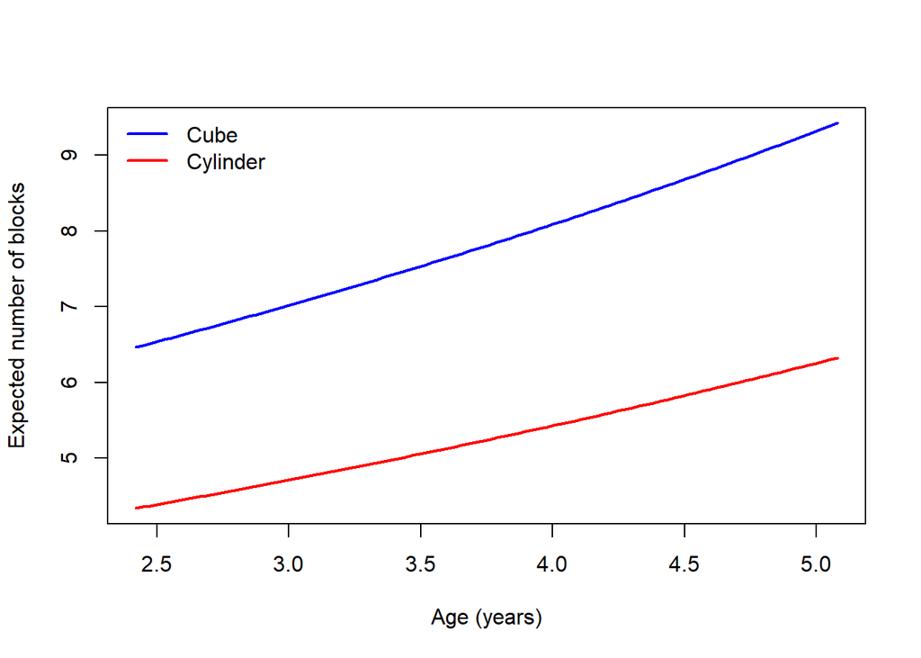

```r
yr <- range(c(mu_cube, mu_cyl), finite = TRUE)

plot(age_seq, mu_cube, type = "l",
     ylim = yr,
     xlab = "Age (years)",
     ylab = "Expected number of blocks",
     col = "blue", lwd = 2)

lines(age_seq, mu_cyl, col = "red", lwd = 2)

legend("topleft",
       legend = c("Cube", "Cylinder"),
       col = c("blue", "red"),
       lwd = 2, bty = "n")
```